# Flights Data Exploration

### by Sherif Essam

## Preliminary Wrangling

> The dataset used contains the flights made on different airports during August 2020, total delay with all its reasons and number of all cancelled flights for each airport and carrier.

By looking at all delay columns we can see that arr_delay represent all the delay (in minutes) that was caused by the five reasons (carrier-weaher-NAS-security-late aircraft).

## Data Exploration :

#### Cancelled flights distribution

Let's look at the distribution of arr_cancelled (number of cancelled flights) :

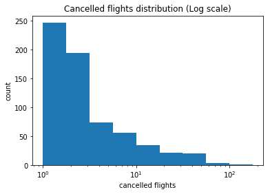

```python
bins = 10 ** np.arange(0 , np.log10(df['arr_cancelled'].max())+ 0.25 , 0.25)
plt.hist(data=df , x='arr_cancelled' , bins=bins);
plt.xscale('log');
plt.xlabel('cancelled flights');
plt.ylabel('count')
plt.title('Cancelled flights distribution (Log scale)');
```

It seems that log scale is much more useful and we can see that number of cancelled flights is less than 10 flights in most cases with less than 200 at its maximum.

#### Flights delay distribution

Let's look at the distribution of the total flights delay (in minutes) :

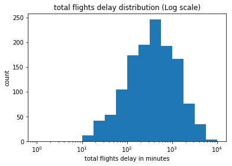

```python
log_binsize = 0.25
bins = 10 ** np.arange(0 , np.log10(df['arr_delay'].max())+log_binsize , log_binsize)
plt.hist(data=df , x='arr_delay' , bins=bins);
plt.xscale('log')
plt.xlabel('total flights delay in minutes');
plt.ylabel('count')
plt.title('total flights delay distribution (Log scale)');
```

From the graph we can figure out that most of the flights occured with between 100 and 1000 minutes as a total delay.

#### Carriers distribution

How many carriers are there in our data? Is their distibution balanced?

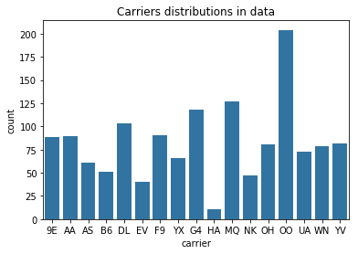

```python
base_color = sb.color_palette()[0]
sb.countplot(data=df , x='carrier' , color = base_color);
plt.title('Carriers distributions in data');
```

Carriers distribution is not balanced as shown above, there are some carriers that appear in our data more than others.

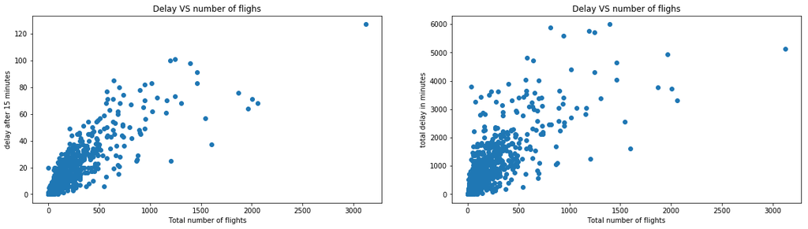

```python
plt.figure(figsize = [20, 5])

plt.subplot(1, 2, 1)
plt.scatter(data=df , x='arr_flights' , y='arr_del15');
plt.xlabel('Total number of flights');
plt.ylabel('delay after 15 minutes')
plt.title('Delay VS number of flighs');

plt.subplot(1, 2, 2)
plt.scatter(data=df , x='arr_flights' , y='arr_delay');
plt.xlabel('Total number of flights');
plt.ylabel('total delay in minutes')
plt.title('Delay VS number of flighs');
```

As shown from the graphs and also as expected, delay time is directly proportional to the total number of flights. So, when we study all delay variables we should take into consideration the number of flights.

#### Flights delay reasons :

We knew from the beginning that the total delay is the sum of 5 reasons of delays. Now, lets draw total delay with all these reasons to know which one affects the total delay the most.

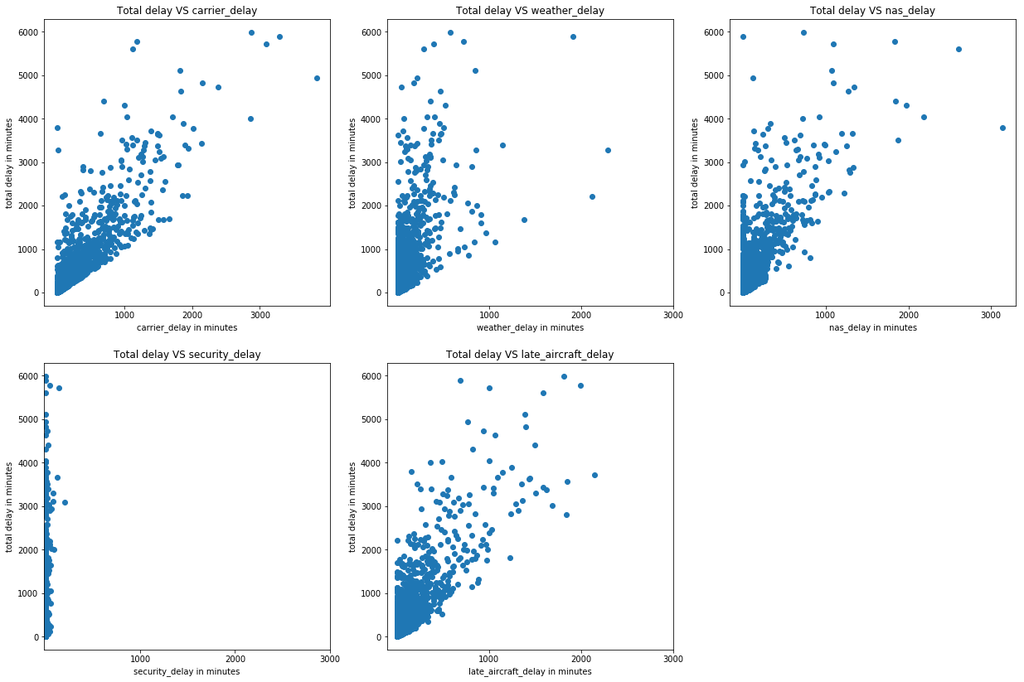

```python
plt.figure(figsize = [21, 14])

plt.subplot(2, 3, 1)
plt.scatter(data=df , x='carrier_delay' , y='arr_delay');
plt.xticks(np.arange(1000,4000,1000));
plt.xlabel('carrier_delay in minutes');
plt.ylabel('total delay in minutes')
plt.title('Total delay VS carrier_delay');

plt.subplot(2, 3, 2)
plt.scatter(data=df , x='weather_delay' , y='arr_delay');
plt.xticks(np.arange(1000,4000,1000));
plt.xlabel('weather_delay in minutes');
plt.ylabel('total delay in minutes')
plt.title('Total delay VS weather_delay');

plt.subplot(2, 3, 3)
plt.scatter(data=df , x='nas_delay' , y='arr_delay');
plt.xticks(np.arange(1000,4000,1000));
plt.xlabel('nas_delay in minutes');
plt.ylabel('total delay in minutes')
plt.title('Total delay VS nas_delay');

plt.subplot(2, 3, 4)
plt.scatter(data=df , x='security_delay' , y='arr_delay');
plt.xticks(np.arange(1000,4000,1000));
plt.xlabel('security_delay in minutes');
plt.ylabel('total delay in minutes')
plt.title('Total delay VS security_delay');

plt.subplot(2, 3, 5)
plt.scatter(data=df , x='late_aircraft_delay' , y='arr_delay');
plt.xticks(np.arange(1000,4000,1000));
plt.xlabel('late_aircraft_delay in minutes');
plt.ylabel('total delay in minutes')
plt.title('Total delay VS late_aircraft_delay');
```

We can see that security delay is very low and almost not effective to the total delay. The remaining four reasons are effective and their distibutions are close to each other with slight increase in carrier delay.

#### Carriers, their delay and cancelled flights

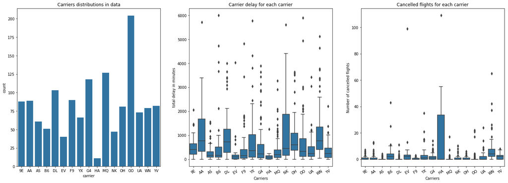

```python
plt.figure(figsize = [24, 8])

plt.subplot(1, 3, 1)
base_color = sb.color_palette()[0]
sb.countplot(data=df , x='carrier' , color = base_color);
plt.title('Carriers distributions in data');

plt.subplot(1, 3, 2)
base_color = sb.color_palette()[0]
sb.boxplot(data=df , x='carrier' , y='arr_delay' , color = base_color);
plt.xticks(rotation=30);
plt.xlabel('Carriers');
plt.ylabel('total delay in minutes')
plt.title('Carrier delay for each carrier');

plt.subplot(1, 3, 3)
base_color = sb.color_palette()[0]
sb.boxplot(data=df , x='carrier' , y='arr_cancelled' , color = base_color);
plt.xticks(rotation=30);
plt.xlabel('Carriers');
plt.ylabel('Number of cancelled flights')
plt.title('Cancelled flights for each carrier');
```

#### Delay variables vs ct variables

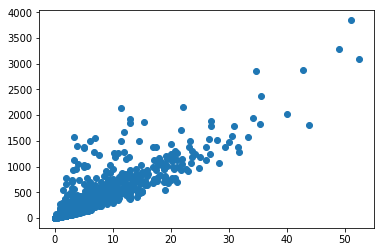

```python
plt.scatter(data=df , x='carrier_ct' , y='carrier_delay');
```

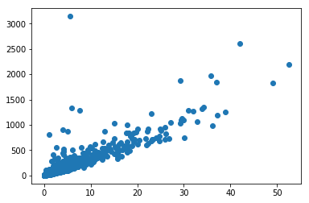

```python
plt.scatter(data=df , x='nas_ct' , y='nas_delay');
```

## Multivariate Exploration

Multivariate plot between carrier_ct, carrier delay and cancelled flights might ensures the insight we gained before :

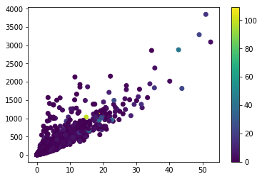

```python
plt.scatter(data = df, x = 'carrier_ct', y = 'carrier_delay', c = 'arr_cancelled');

plt.colorbar()
```

The plot above ensures our earlier conclusions that carrier delay is directly proportional to carrier_ct but cancelled flight in each carrier does not depend on the two variables.